# Pizza sales demand prediction using Machine Learning Pipeline

**Name:** Gaurav Tiwari  
**Student ID:** GH1054294  
**Module:** M606 Machine Learning  
**Dataset:** Pizza Sales  
**Dataset URL:** https://www.kaggle.com/datasets/purusachdeva/dominos-pizza-sales  
To predict the demand of pizza and the sales of pizzas, the concept of machine learning pipeline were used.  
The workflow include, data exploration , data preprocessing, feature engineering, train test split, model training and final evaluation.

```python
import pandas as pd
import numpy as np
import matplotlib.pyplot as plt
import seaborn as sns

from sklearn.model_selection import train_test_split
from sklearn.preprocessing import LabelEncoder
from sklearn.metrics import mean_squared_error, r2_score

from sklearn.linear_model import LinearRegression
from sklearn.ensemble import RandomForestRegressor
```

## 1. Problem Statement

The main objective of this project is to analyse the pizza sales data from the chosen dataset and to build the machine learning model through pipeline method which predicts the pizza demands based on available records.  
This model can help the pizza related franchise to improve the stock planning , ingredient management and sales advertising.  
The target variable for our this machine learning model would be pizza *quantity sold*, which directly represent the pizza demand. Additionally, it will help the business to predict about the inventory planning and future demand.

```python
df = pd.read_csv('pizza_sales.csv')
```

```python
df.head(100)
```

|  | pizza_id | order_id | pizza_name_id | quantity | order_date | order_time | unit_price | total_price | pizza_size | pizza_category | pizza_ingredients | pizza_name |
| --- | --- | --- | --- | --- | --- | --- | --- | --- | --- | --- | --- | --- |
| 0 | 1 | 1 | hawaiian_m | 1 | 2015-01-01 | 11:38:36 | 13.25 | 13.25 | M | Classic | Sliced Ham, Pineapple, Mozzarella Cheese | The Hawaiian Pizza |
| 1 | 2 | 2 | classic_dlx_m | 1 | 2015-01-01 | 11:57:40 | 16.00 | 16.00 | M | Classic | Pepperoni, Mushrooms, Red Onions, Red Peppers,... | The Classic Deluxe Pizza |
| 2 | 3 | 2 | five_cheese_l | 1 | 2015-01-01 | 11:57:40 | 18.50 | 18.50 | L | Veggie | Mozzarella Cheese, Provolone Cheese, Smoked Go... | The Five Cheese Pizza |
| 3 | 4 | 2 | ital_supr_l | 1 | 2015-01-01 | 11:57:40 | 20.75 | 20.75 | L | Supreme | Calabrese Salami, Capocollo, Tomatoes, Red Oni... | The Italian Supreme Pizza |
| 4 | 5 | 2 | mexicana_m | 1 | 2015-01-01 | 11:57:40 | 16.00 | 16.00 | M | Veggie | Tomatoes, Red Peppers, Jalapeno Peppers, Red O... | The Mexicana Pizza |
| ... | ... | ... | ... | ... | ... | ... | ... | ... | ... | ... | ... | ... |
| 95 | 96 | 39 | ital_supr_l | 1 | 2015-01-01 | 17:07:23 | 20.75 | 20.75 | L | Supreme | Calabrese Salami, Capocollo, Tomatoes, Red Oni... | The Italian Supreme Pizza |
| 96 | 97 | 40 | four_cheese_l | 1 | 2015-01-01 | 17:14:36 | 17.95 | 17.95 | L | Veggie | Ricotta Cheese, Gorgonzola Piccante Cheese, Mo... | The Four Cheese Pizza |
| 97 | 98 | 40 | southw_ckn_s | 1 | 2015-01-01 | 17:14:36 | 12.75 | 12.75 | S | Chicken | Chicken, Tomatoes, Red Peppers, Red Onions, Ja... | The Southwest Chicken Pizza |
| 98 | 99 | 41 | four_cheese_m | 1 | 2015-01-01 | 17:15:20 | 14.75 | 14.75 | M | Veggie | Ricotta Cheese, Gorgonzola Piccante Cheese, Mo... | The Four Cheese Pizza |
| 99 | 100 | 41 | green_garden_s | 1 | 2015-01-01 | 17:15:20 | 12.00 | 12.00 | S | Veggie | Spinach, Mushrooms, Tomatoes, Green Olives, Fe... | The Green Garden Pizza |

100 rows × 12 columns

## 2. Dataset Overview

Before starting any operation on the dataset, its better to understand data structure and the available features of it.  
The dataset contains variables such as pizza type, pizza quantity, order date, price, size and ingredients.  
These rows are useful to perfrom both business analysis and machine learning modelling.

```python
df.info()
```

```
<class 'pandas.DataFrame'>
RangeIndex: 48620 entries, 0 to 48619
Data columns (total 12 columns):
 #   Column             Non-Null Count  Dtype
---  ------             --------------  -----
 0   pizza_id           48620 non-null  int64
 1   order_id           48620 non-null  int64
 2   pizza_name_id      48620 non-null  str
 3   quantity           48620 non-null  int64
 4   order_date         48620 non-null  str
 5   order_time         48620 non-null  str
 6   unit_price         48620 non-null  float64
 7   total_price        48620 non-null  float64
 8   pizza_size         48620 non-null  str
 9   pizza_category     48620 non-null  str
 10  pizza_ingredients  48620 non-null  str
 11  pizza_name         48620 non-null  str
dtypes: float64(2), int64(3), str(7)
memory usage: 4.5 MB
```

The given information shows the dataset size such as number of rows/columns, datatypes and non-null values.

From the output,it describes that the dataset contains both numerical and categorical variables which means data preprocessing required before applying machine learning algorithm, so the model can learn correctly and produce accurate predictions.

```python
df.shape
```

```
(48620, 12)
```

The shape property describes the dimension of the dataset

```python
df.describe()
```

|  | pizza_id | order_id | quantity | unit_price | total_price |
| --- | --- | --- | --- | --- | --- |
| count | 48620.000000 | 48620.000000 | 48620.000000 | 48620.000000 | 48620.000000 |
| mean | 24310.500000 | 10701.479761 | 1.019622 | 16.494132 | 16.821474 |
| std | 14035.529381 | 6180.119770 | 0.143077 | 3.621789 | 4.437398 |
| min | 1.000000 | 1.000000 | 1.000000 | 9.750000 | 9.750000 |
| 25% | 12155.750000 | 5337.000000 | 1.000000 | 12.750000 | 12.750000 |
| 50% | 24310.500000 | 10682.500000 | 1.000000 | 16.500000 | 16.500000 |
| 75% | 36465.250000 | 16100.000000 | 1.000000 | 20.250000 | 20.500000 |
| max | 48620.000000 | 21350.000000 | 4.000000 | 35.950000 | 83.000000 |

The descriptive property gives an overview of the numerical variables such as quanity , unit price and total price. which would help to understand the basic business pattern of the chosen dataset before deeper analysis.

## 3.1 Data Quality Check

Before applying machine learning , let's verify whether our dataset contains any missing values, empty cells or duplicate value to ensure the data is clean and reliable.

```python
df.isnull().sum()
```

```
pizza_id             0
order_id             0
pizza_name_id        0
quantity             0
order_date           0
order_time           0
unit_price           0
total_price          0
pizza_size           0
pizza_category       0
pizza_ingredients    0
pizza_name           0
dtype: int64
```

The output shows no missing values and empty cells are there in the dataset.

```python
df.duplicated().sum()
```

```
np.int64(0)
```

The following result ensure that there is no duplication in the dataset.

so from the outcome of last operations ensure that the dataset is already clean and suitable for further model learning.

## 3.2 Pizza Size Distribution

The graphh shows the sales distribution across the different sizes of pizza, which helps to identify the most preferred pizza by the customers.

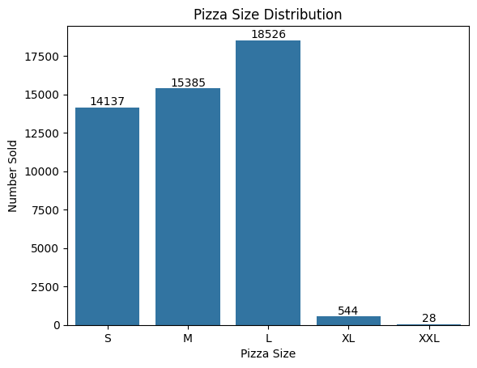

```python
order = ["S", "M", "L", "XL", "XXL"]

ax = sns.countplot(x="pizza_size", data=df, order=order)

for container in ax.containers:
    ax.bar_label(container)

plt.title("Pizza Size Distribution")
plt.xlabel("Pizza Size")
plt.ylabel("Number Sold")

plt.show()
```

From the graph , it is clearly noticable that Large size pizza are on high demands by the customers, which can help the business to improve the inventory planning andproduct preparation.

## 3.3 Ingredient Analysis

To study all the ingredients properly or to identify which ingredient has been used the most we have divided it into indiviual column for better practices.

```python
ingredient_features = df["pizza_ingredients"].str.get_dummies(sep=",")
```

```python
df.head()
```

|  | pizza_id | order_id | pizza_name_id | quantity | order_date | order_time | unit_price | total_price | pizza_size | pizza_category | pizza_ingredients | pizza_name |
| --- | --- | --- | --- | --- | --- | --- | --- | --- | --- | --- | --- | --- |
| 0 | 1 | 1 | hawaiian_m | 1 | 2015-01-01 | 11:38:36 | 13.25 | 13.25 | M | Classic | Sliced Ham, Pineapple, Mozzarella Cheese | The Hawaiian Pizza |
| 1 | 2 | 2 | classic_dlx_m | 1 | 2015-01-01 | 11:57:40 | 16.00 | 16.00 | M | Classic | Pepperoni, Mushrooms, Red Onions, Red Peppers,... | The Classic Deluxe Pizza |
| 2 | 3 | 2 | five_cheese_l | 1 | 2015-01-01 | 11:57:40 | 18.50 | 18.50 | L | Veggie | Mozzarella Cheese, Provolone Cheese, Smoked Go... | The Five Cheese Pizza |
| 3 | 4 | 2 | ital_supr_l | 1 | 2015-01-01 | 11:57:40 | 20.75 | 20.75 | L | Supreme | Calabrese Salami, Capocollo, Tomatoes, Red Oni... | The Italian Supreme Pizza |
| 4 | 5 | 2 | mexicana_m | 1 | 2015-01-01 | 11:57:40 | 16.00 | 16.00 | M | Veggie | Tomatoes, Red Peppers, Jalapeno Peppers, Red O... | The Mexicana Pizza |

## 3.4 Ingredient frequency analyis

Ingredient values are seperated into binary column and counted seperately inorder to understand which ingredients are getting used more so the business can prepare the stocks in advanced.

```python
ingredient_features.head()
```

|  | Alfredo Sauce | Anchovies | Artichoke | Artichokes | Arugula | Asiago Cheese | Bacon | Barbecue Sauce | Beef Chuck Roast | Blue Cheese | ... | Kalamata Olives | Mozzarella Cheese | Mushrooms | Pepperoni | Prosciutto di San Daniele | Ricotta Cheese | Sliced Ham | Soppressata Salami | Spinach | Tomatoes |
| --- | --- | --- | --- | --- | --- | --- | --- | --- | --- | --- | --- | --- | --- | --- | --- | --- | --- | --- | --- | --- | --- |
| 0 | 0 | 0 | 0 | 0 | 0 | 0 | 0 | 0 | 0 | 0 | ... | 0 | 0 | 0 | 0 | 0 | 0 | 1 | 0 | 0 | 0 |
| 1 | 0 | 0 | 0 | 0 | 0 | 0 | 1 | 0 | 0 | 0 | ... | 0 | 0 | 0 | 1 | 0 | 0 | 0 | 0 | 0 | 0 |
| 2 | 0 | 0 | 0 | 0 | 0 | 0 | 0 | 0 | 0 | 1 | ... | 0 | 1 | 0 | 0 | 0 | 0 | 0 | 0 | 0 | 0 |
| 3 | 0 | 0 | 0 | 0 | 0 | 0 | 0 | 0 | 0 | 0 | ... | 0 | 0 | 0 | 0 | 0 | 0 | 0 | 0 | 0 | 0 |
| 4 | 0 | 0 | 0 | 0 | 0 | 0 | 0 | 0 | 0 | 0 | ... | 0 | 0 | 0 | 0 | 0 | 0 | 0 | 0 | 0 | 1 |

5 rows × 73 columns

```python
df = pd.concat([df, ingredient_features], axis=1)
```

```python
df.shape
```

```
(48620, 85)
```

```python
ingredient_usage = ingredient_features.sum().sort_values(ascending=False)

ingredient_usage.head(10)
```

```
 Garlic               27422
 Tomatoes             23694
 Red Onions           19547
 Red Peppers          16284
Chicken                8443
 Mushrooms             8114
 Mozzarella Cheese     6605
 Pepperoni             6542
 Green Olives          6174
 Artichokes            5682
dtype: int64
```

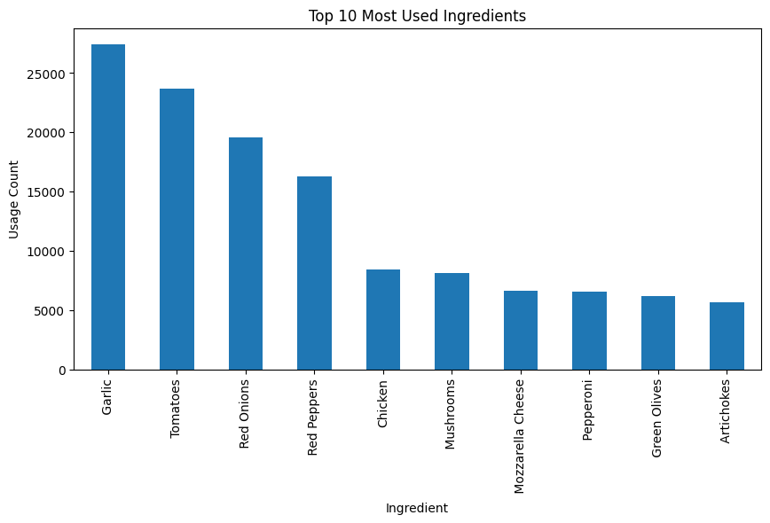

```python
ingredient_usage.head(10).plot(kind="bar", figsize=(10,5))

plt.title("Top 10 Most Used Ingredients")
plt.xlabel("Ingredient")
plt.ylabel("Usage Count")

plt.show()
```

The above graph shows that the Garlic , tomatoes and red onions are one of the highest used ingredients in the pizza production.

## 3.5 Time based feature Engineering

Date and time field are also divided into indiviual columns such as month, day of week, weekend and hour inorder to understand on which particular time period the pizza has been sold much. So the business can planned more employees in such time for pizza production.

```python
df["order_date"] = pd.to_datetime(df["order_date"])
```

```python
df["month"] = df["order_date"].dt.month
df["day_of_week"] = df["order_date"].dt.dayofweek
df["day_name"] = df["order_date"].dt.day_name()
```

```python
df["is_weekend"] = df["day_of_week"].apply(lambda x: 1 if x >= 5 else 0)
```

```python
df["order_time"] = pd.to_datetime(df["order_time"], format="%H:%M:%S")
```

```python
df["hour"] = df["order_time"].dt.hour
df["minute"] = df["order_time"].dt.minute
```

```python
def time_period(hour):
    if hour < 12:
        return "Morning"
    elif hour < 17:
        return "Afternoon"
    elif hour < 21:
        return "Evening"
    else:
        return "Night"

df["time_period"] = df["hour"].apply(time_period)
```

```python
df.head()
```

|  | pizza_id | order_id | pizza_name_id | quantity | order_date | order_time | unit_price | total_price | pizza_size | pizza_category | ... | Soppressata Salami | Spinach | Tomatoes | month | day_of_week | day_name | is_weekend | hour | minute | time_period |
| --- | --- | --- | --- | --- | --- | --- | --- | --- | --- | --- | --- | --- | --- | --- | --- | --- | --- | --- | --- | --- | --- |
| 0 | 1 | 1 | hawaiian_m | 1 | 2015-01-01 | 1900-01-01 11:38:36 | 13.25 | 13.25 | M | Classic | ... | 0 | 0 | 0 | 1 | 3 | Thursday | 0 | 11 | 38 | Morning |
| 1 | 2 | 2 | classic_dlx_m | 1 | 2015-01-01 | 1900-01-01 11:57:40 | 16.00 | 16.00 | M | Classic | ... | 0 | 0 | 0 | 1 | 3 | Thursday | 0 | 11 | 57 | Morning |
| 2 | 3 | 2 | five_cheese_l | 1 | 2015-01-01 | 1900-01-01 11:57:40 | 18.50 | 18.50 | L | Veggie | ... | 0 | 0 | 0 | 1 | 3 | Thursday | 0 | 11 | 57 | Morning |
| 3 | 4 | 2 | ital_supr_l | 1 | 2015-01-01 | 1900-01-01 11:57:40 | 20.75 | 20.75 | L | Supreme | ... | 0 | 0 | 0 | 1 | 3 | Thursday | 0 | 11 | 57 | Morning |
| 4 | 5 | 2 | mexicana_m | 1 | 2015-01-01 | 1900-01-01 11:57:40 | 16.00 | 16.00 | M | Veggie | ... | 0 | 0 | 1 | 1 | 3 | Thursday | 0 | 11 | 57 | Morning |

5 rows × 92 columns

The dataset now consists indiviual columns related to time periods which help the business to improve employee planning for pizza production.

## 3.6 Sales performance analysis

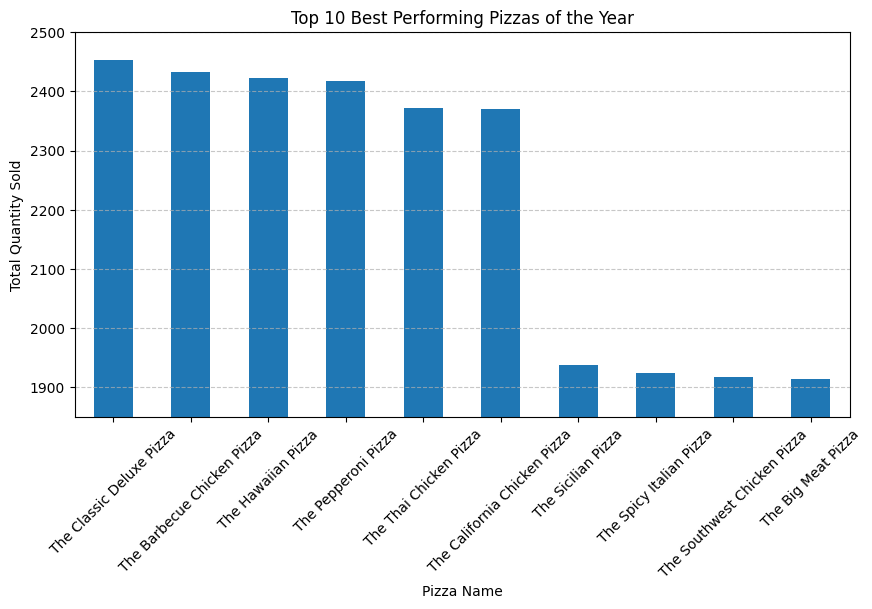

```python
top_pizzas = df.groupby("pizza_name")["quantity"].sum()

top_pizzas = top_pizzas.sort_values(ascending=False).head(10)

plt.figure(figsize=(10,5))

top_pizzas.plot(kind="bar")

plt.title("Top 10 Best Performing Pizzas of the Year")
plt.xlabel("Pizza Name")
plt.ylabel("Total Quantity Sold")

plt.xticks(rotation=45)
plt.ylim(1850, 2500)
plt.grid(axis="y", linestyle="--", alpha=0.7)

plt.show()
```

From the graph, it shows the 6 main pizza such as The classic Deluxe, The Barbecue chicken, The Hawaiian , The Pepperoni, The Thai Chicken and The Califoria Chicken pizza has been sold the most throughout the year and contribuate the most in business revenue. This information will help business to keep such pizzas into the food menu.

```python
df["revenue"] = df["quantity"] * df["unit_price"]
```

```python
top_revenue = df.groupby("pizza_name")["revenue"].sum().sort_values(ascending=False).head(10)
```

```python
df["total_price"] = df["quantity"] * df["unit_price"]
```

```python
top10 = df.groupby("pizza_name").agg({
    "quantity": "sum",
    "total_price": "sum"
}).sort_values("quantity", ascending=False).head(10)
```

```python
monthly_sales = df.groupby(["month","pizza_name"])["quantity"].sum().reset_index()
```

```python
max_monthly_sales = monthly_sales.loc[
    monthly_sales.groupby("month")["quantity"].idxmax()
]
```

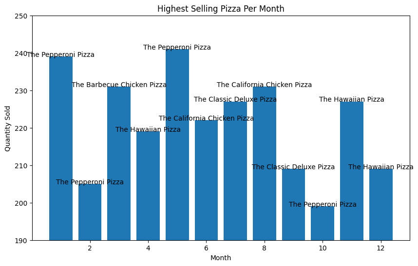

```python
plt.figure(figsize=(10,6))

plt.bar(max_monthly_sales["month"], max_monthly_sales["quantity"])

for i, pizza in enumerate(max_monthly_sales["pizza_name"]):
    plt.text(max_monthly_sales["month"].iloc[i],
             max_monthly_sales["quantity"].iloc[i],
             pizza,
             ha='center')

plt.title("Highest Selling Pizza Per Month")
plt.xlabel("Month")
plt.ylabel("Quantity Sold")
plt.ylim(190, 250)

plt.show()
```

From the graph, it clearly shown how the pizza demands are changing over time , which will help the business to higher demand periods and plan inventory more effectively.

## 4. Data preprocessing and Feature engineering

After exploring the datset and business analysis, the dataset is ready for machine learning. In this phase categorical variables are encoded into numerical because machine learning only understands number and for better accuracy the unnecessary columns would be removed.

```python
df_ml = df.copy()
```

```python
df_ml = df_ml.drop(
    ["pizza_name", "pizza_ingredients", "order_date", "order_time", "pizza_name_id"],
    axis=1,
    errors="ignore"
)
```

```python
df_ml["pizza_category"] = df_ml["pizza_category"].astype(str).str.strip()
df_ml["day_name"] = df_ml["day_name"].astype(str).str.strip()
df_ml["time_period"] = df_ml["time_period"].astype(str).str.strip()
df_ml["pizza_size"] = df_ml["pizza_size"].astype(str).str.strip()
```

```python
df_ml["pizza_size"] = df_ml["pizza_size"].map({"S": 0, "M": 1, "L": 2, "XL": 3, "XXL": 4})
```

```python
pizza_cat_dummies = pd.get_dummies(
    df_ml["pizza_category"], prefix="category", drop_first=True, dtype=int
)
df_ml = pd.concat([df_ml, pizza_cat_dummies], axis=1)
df_ml = df_ml.drop("pizza_category", axis=1)
```

```python
day_dummies = pd.get_dummies(
    df_ml["day_name"], prefix="day", drop_first=True, dtype=int
)
df_ml = pd.concat([df_ml, day_dummies], axis=1)
df_ml = df_ml.drop("day_name", axis=1)
```

```python
time_dummies = pd.get_dummies(
    df_ml["time_period"], prefix="time", drop_first=True, dtype=int
)
df_ml = pd.concat([df_ml, time_dummies], axis=1)
df_ml = df_ml.drop("time_period", axis=1)
```

```python
df_ml.head()
```

|  | pizza_id | order_id | quantity | unit_price | total_price | pizza_size | Alfredo Sauce | Anchovies | Artichoke | Artichokes | ... | category_Veggie | day_Monday | day_Saturday | day_Sunday | day_Thursday | day_Tuesday | day_Wednesday | time_Evening | time_Morning | time_Night |
| --- | --- | --- | --- | --- | --- | --- | --- | --- | --- | --- | --- | --- | --- | --- | --- | --- | --- | --- | --- | --- | --- |
| 0 | 1 | 1 | 1 | 13.25 | 13.25 | 1 | 0 | 0 | 0 | 0 | ... | 0 | 0 | 0 | 0 | 1 | 0 | 0 | 0 | 1 | 0 |
| 1 | 2 | 2 | 1 | 16.00 | 16.00 | 1 | 0 | 0 | 0 | 0 | ... | 0 | 0 | 0 | 0 | 1 | 0 | 0 | 0 | 1 | 0 |
| 2 | 3 | 2 | 1 | 18.50 | 18.50 | 2 | 0 | 0 | 0 | 0 | ... | 1 | 0 | 0 | 0 | 1 | 0 | 0 | 0 | 1 | 0 |
| 3 | 4 | 2 | 1 | 20.75 | 20.75 | 2 | 0 | 0 | 0 | 0 | ... | 0 | 0 | 0 | 0 | 1 | 0 | 0 | 0 | 1 | 0 |
| 4 | 5 | 2 | 1 | 16.00 | 16.00 | 1 | 0 | 0 | 0 | 0 | ... | 1 | 0 | 0 | 0 | 1 | 0 | 0 | 0 | 1 | 0 |

5 rows × 97 columns

```python
df_ml.select_dtypes(include="object").columns
```

```
Index([], dtype='str')
```

All the columns which were needed for model traning were encoded and convert into numerical values and the columns which were not necessary have been removed entirely.

```python
X = df_ml.drop("quantity", axis=1)
```

```python
y = df_ml["quantity"]
```

```python
X.select_dtypes(include="object").columns
```

```
Index([], dtype='str')
```

# 5. Machine learning model training

The dataset was divided into training(80%) and testing(20%) parts inorder to learn from the past data and later in the future it would be able to use on new data(unseen data).

```python
x_train, x_test, y_train, y_test = train_test_split(X,y,test_size=0.2,random_state=42)
```

```python
x_train.shape
```

```
(38896, 96)
```

```python
x_test.shape
```

```
(9724, 96)
```

```python
 y_train.shape
```

```
(38896,)
```

```python
y_test.shape
```

```
(9724,)
```

```python
#Linear Regression
lr = LinearRegression()
```

```python
lr.fit(x_train, y_train)
```

```
LinearRegression()
```

```python
pred_lr = lr.predict(x_test)
```

# 6. Model Evaluation

Mean Squared Error and R² Score method were used to evaluated the trained model to measure the prediction accuracy.

```python
#lets Calculate Mean Squared Error (MSE)
mse_lr = mean_squared_error(y_test, pred_lr)
```

```python
print("Linear Regression MSE:", mse_lr)
```

```
Linear Regression MSE: 0.0010854644727259497
```

```python
#and now calculate R² Score
r2_lr = r2_score(y_test, pred_lr)
```

```python
print("Linear Regression R2 Score:", r2_lr)
```

```
Linear Regression R2 Score: 0.9497688201806773
```

```python
#Random Forest
rf = RandomForestRegressor(n_estimators=100, random_state=42)
```

```python
rf.fit(x_train, y_train)
```

```
RandomForestRegressor(random_state=42)
```

```python
pred_rf = rf.predict(x_test)
```

```python
mse_rf = mean_squared_error(y_test, pred_rf)
```

```python
print("Random Forest MSE:", mse_rf)
```

```
Random Forest MSE: 4.6596051007815694e-05
```

```python
r2_rf = r2_score(y_test, pred_rf)
```

```python
print("Random Forest R2 Score:", r2_rf)
```

```
Random Forest R2 Score: 0.9978437114471688
```

# 7. Results

The Random Forest model shows the lowest prediction errors as compared to the Linear regression model, which indicates that Random Forest model has better prediction performance on this chosen dataset as well as it also suggests that the model can capture pizza sales pattern effectively.

## Features Importance Analysis

The Random forest model also help to find out which factor are affecting the pizza demand the most. the graph below shows the top features contributing.

```python
#final plotting of graph
feature_importance = pd.Series(
    rf.feature_importances_,
    index=X.columns
).sort_values(ascending=False)
```

```python
top_features = feature_importance.head(10)
```

```python
print(top_features)
```

```
total_price          0.399819
revenue              0.377713
pizza_size           0.102155
unit_price           0.097213
category_Classic     0.009897
 Garlic              0.007603
 Beef Chuck Roast    0.001051
Kalamata Olives      0.000728
 Italian Sausage     0.000566
 Feta Cheese         0.000484
dtype: float64
```

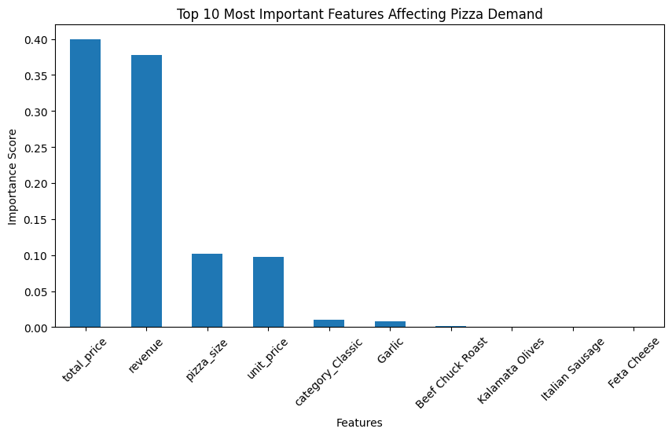

```python
plt.figure(figsize=(10,5))

top_features.plot(kind="bar")

plt.title("Top 10 Most Important Features Affecting Pizza Demand")

plt.xlabel("Features")
plt.ylabel("Importance Score")

plt.xticks(rotation=45)

plt.show()
```

## 8. Final Discussion

The machine learning analysis has been carried out for understaning the patterns of pizza sales demand using the past records.Before the model trained , the dataset has been understood properly and later operations like preprocessing has been done inorder to remove duplication , missing value or to encode the categorial variables to numerical values. The transformation of text based value to numeric was mandatory as the machine learning only understands numbers.

Two regression model were applied in this study which was Linear regression and Random forest model.Mean Squared Error and R² Score method used on both model, in which random forest model shown the lowest prediction errors and highest accuracy. That proves the random forest model are more effective in catching the complex connection within the chosen dataset which is one of the strongest point of this model.

Random Forest model showed that the pizza demands are highly affected by Total price , revenue , pizza's size and unit price of the pizza, which means both product pricing and orders characteristics plays a crucial role in customer buying patterns. There is one limitation about this model, that it can only predict on the past data from which holidays , events , promotions or seasonal treands are excluded, which might influence the demand of pizza business.

That means Machine learning can be applied to the pizza sales to support the decision making on the base of past data. It can help the businesses to understand the customer behaviour of demands for upcoming month/year , in planning of inventory and reasonable pricing according to the pizza to earn more profit.

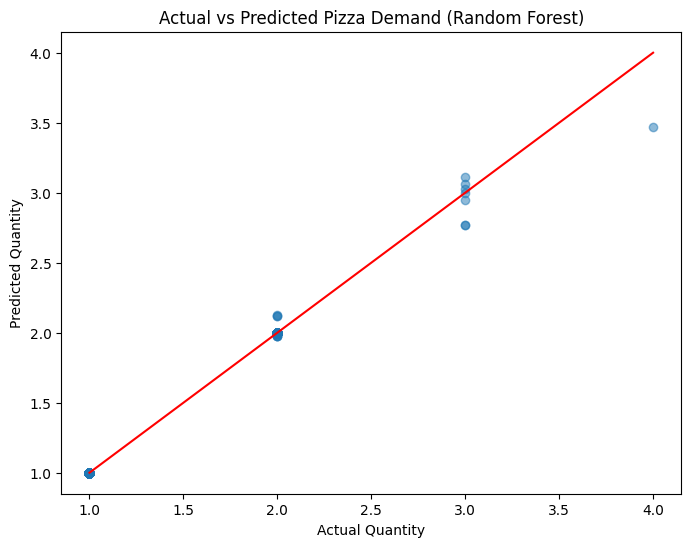

```python
plt.figure(figsize=(8,6))

plt.scatter(y_test, pred_rf, alpha=0.5)

plt.plot([y_test.min(), y_test.max()],
         [y_test.min(), y_test.max()],
         color="red")

plt.title("Actual vs Predicted Pizza Demand (Random Forest)")
plt.xlabel("Actual Quantity")
plt.ylabel("Predicted Quantity")

plt.show()
```